# Example RNA-Seq Program for Paired-End RNA

### Project Folder Set-Up

It is easiest to follow along with this guide, if you set up a project folder that contains the following subfolders:

- rawReads - should contain the original fastq files
- trimmedReads
- alignedReads
- data
- programs
- quantitation

## 1. Unzip Files

```
/projectFolder/unzip.sh &
```

## 2. Determine number of reads sent for each sample

For this program, you want to make double check the header on the fastq file. For my example code, my fastq file entry looks like this.

```
@GWZHISEQ02:301:C97NKANXX:3:1101:1486:1895 1:N:0:CGGCTATG
NTCCGGTCTGAACTCAGATCACGTAGGACTTTAATCGTTGAACAAACGAACCATTAATAGCNTCTGCACCATTGGGATGTCCTGATCCAACAGATCGGAAG
+
#<<BB/BFFFFFFFFFFFFFFFBFFFFFF<BBBF/FB<BFFFFFFFFFFFFF/<<FF<<<F#/<<<FFFFFF/FF<FBF/</F/FBFFFFFFBF/F/7BF/
```

The header row starts with @GWZHISEQ. In the program that counts reads, it looks for this header row to indicate a new read.

This is the code in countRawReads.sh

```
#!/bin/bash
FILES1=/projectFolder/rawReads/*.fastq
for f in $FILES1
do
    awk '/@GWZHISEQ/ {getline; print length($0)}' $f | awk -v sample="$f" '{sum+=$1} END {print sample,sum/NR,NR}' >> /projectFolder/data/rawReadCounts.txt
done
```

You will have to change ‘projectFolder’ to the pathway to the project folder that you set up initially. The '@GWZHISEQ‘should be changed to the appropriate indicator for the header. The core here on campus uses’@HISEQ’, but it is worth checking the first few lines of one of you files to double check.

```
/projectFolder/countRawReads.sh &
```

The R code below reads in the txt file generated when counting reads per sample. Much of it will have to be changed to get the data to look ‘pretty’ for your particular samples.

```r
rm(list=ls())
options(stringsAsFactors=FALSE)
library(knitr)

projectFolder <- "~/Documents/IntroToRNASeq/"

rawCounts = read.table(file=paste(projectFolder,"data/rawReadCounts.txt",sep=""),sep=" ",header=FALSE,fill=TRUE)

rawCounts$readFrag = as.numeric(rawCounts$V3)
rawCounts$file = unlist(lapply(strsplit(rawCounts$V1,split="/",fixed=TRUE),function(a) a[length(a)]))
rawCounts$sample = unlist(lapply(strsplit(rawCounts$file,split="_",fixed=TRUE),function(a) paste(a[1:2],collapse="_")))

readFragments = aggregate(rawCounts$readFrag,by=list(sample=rawCounts$sample),sum)
readFragments$numPairedReads = prettyNum(readFragments$x/2,big.mark=",",scientific=FALSE)
readFragments$numReadFragments = prettyNum(readFragments$x,big.mark=",",scientific=FALSE)

readFragments=readFragments[,colnames(readFragments)!="x"]
forPrint = readFragments[,c("sample","numPairedReads","numReadFragments")]
colnames(forPrint) = c("sample","Number of Paired-End Reads","Number of Read Fragments")
```

## Raw Reads/Read Fragments

```r
kable(forPrint,align=rep("c",ncol(readFragments)))
```

| sample | Number of Paired-End Reads | Number of Read Fragments |
| --- | --- | --- |
| WT_5 | 10,000 | 20,000 |

Total Number of Paired End Reads: 10,000  
Total Number of Read Fragments: 20,000  
Average Number of Paired End Reads Per Sample: 10,000

## 3. Trim reads for adaptors and for quality

```
/Users/sabal/Documents/SabaLab/examplePrograms/RNASeq/pairedEnd.polyA/trimReads.sh &
```

Here is what that program contains:

```
FILES1=/projectFolder/rawReads/*R1*.fastq
for f in $FILES1
do
    f2=${f//R1/R2}
    f_trimmed=${f//.fastq/_trimmed.fastq}
    f_trimmed=${f_trimmed//rawReads/trimmedReads}
    f2_trimmed=${f2//.fastq/_trimmed.fastq}
    f2_trimmed=${f2_trimmed//rawReads/trimmedReads}
    cutadapt -q 20 -m 20 -a AGATCGGAAGAGCACACGTCTGAACTCCAGTCACCCGTCCCGATCTCGTATGCCGTCTTCTGCTTG -A AGATCGGAAGAGCGTCGTGTAGGGAAAGAGTGTAGATCTCGGTGGTCGCCGTATCATT -o $f_trimmed -p $f2_trimmed $f $f2
done
```

Here is the code to do a single sample

```
cutadapt -q 20 -m 20 -a AGATCGGAAGAGCACACGTCTGAACTCCAGTCACCCGTCCCGATCTCGTATGCCGTCTTCTGCTTG -A AGATCGGAAGAGCGTCGTGTAGGGAAAGAGTGTAGATCTCGGTGGTCGCCGTATCATT -o /projectFolder/trimmedReads/WT_5_CGGCTATG_L003_R1_001_trimmed.fastq -p /projectFolder/trimmedReads/WT_5_CGGCTATG_L003_R2_001_trimmed.fastq /projectFolder/rawReads/WT_5_CGGCTATG_L003_R1_001.fastq /projectFolder/rawReads/WT_5_CGGCTATG_L003_R2_001.fastq
```

Again, you will have to put in the path to the raw data files.

## 4. Characterize Trimmed Reads

The code for counting trimmed reads is very similar to the counting raw reads.

```
/projectFolder/code/countTrimmedReads.sh &
```

Here is what the .sh file contains.

```
#!/bin/bash
FILES1=/projectFolder/trimmedReads/*.fq
for f in $FILES1
do
    awk '/@HWI/ {getline; print length($0)}' $f | awk -v sample="$f" '{sum+=$1} END {print sample,sum/NR,NR}' >> /projectFolder/data/trimmedReadCounts.txt
done
```

This R code just makes the txt file generated easier to read and adds the information on the raw reads.

```r
options(stringsAsFactors=FALSE)

trimmed = read.table(file=paste(projectFolder,"data/trimmedReadCounts.txt",sep=""),sep="",header=FALSE)
trimmed$file = unlist(lapply(strsplit(trimmed$V1,split="/",fixed=TRUE),function(a) a[length(a)]))
trimmed$sample = unlist(lapply(strsplit(trimmed$file,split="_",fixed=TRUE),function(a) paste(a[1:2],collapse="_")))
trimmed$read = unlist(lapply(strsplit(trimmed$file,split="_",fixed=TRUE),function(a) a[5]))
trimmed$lane = unlist(lapply(strsplit(trimmed$file,split="_",fixed=TRUE),function(a) a[4]))

bySample = merge(trimmed[trimmed$read=="R1",c("sample","lane","V2","V3")],trimmed[trimmed$read=="R2",c("sample","V2")],by="sample")
bySample$numReadFrag = bySample$V3*2
colnames(bySample) = c("sample","lane","avgFragLength.R1","numReads","avgFragLength.R2","numReadFrag")

bySample = merge(readFragments,bySample,by=c("sample"))
bySample$pctReadsAfterTrim = paste(sprintf("%.1f",round(100*bySample$numReads/as.numeric(gsub(",","",bySample$numPairedReads)),1)),"%",sep="")

forPrint2 = bySample[,c("sample","numPairedReads","numReadFragments","avgFragLength.R1","avgFragLength.R2","numReadFrag","pctReadsAfterTrim")]
forPrint2$avgFragLength.R1 = sprintf("%.1f",round(forPrint2$avgFragLength.R1,1))
forPrint2$avgFragLength.R2 = sprintf("%.1f",round(forPrint2$avgFragLength.R2,1))
forPrint2$numReadFrag = prettyNum(forPrint2$numReadFrag,big.mark=",")

colnames(forPrint2) = c("sample","Number of Paired-End Reads","Number of Read Fragments","Average Read Fragment Length After Trimming (first read fragment)","Average Read Fragment Length After Trimming (second read fragment)","Number of Read Fragments After Trimming","Percent of Read Fragments That Remained After Trimming")
```

## Trimmed Reads/Read Fragments

```r
kable(forPrint2,align=rep("c",ncol(forPrint2)))
```

| sample | Number of Paired-End Reads | Number of Read Fragments | Average Read Fragment Length After Trimming (first read fragment) | Average Read Fragment Length After Trimming (second read fragment) | Number of Read Fragments After Trimming | Percent of Read Fragments That Remained After Trimming |
| --- | --- | --- | --- | --- | --- | --- |
| WT_5 | 10,000 | 20,000 | 98.5 | 98.4 | 19,802 | 99.0% |

Total Number of Paired End Reads After Trimming: 9,901  
Total Number of Read Fragments After Trimming: 19,802  
Average Number of Paired End Reads Per Sample After Trimming: 9,901

## 5. Align trimmed reads to genome

First, you need to download the most recent version of the genome from Ensembl, e.g., ftp://ftp.ensembl.org/pub/release-87/fasta/rattus_norvegicus/dna/Rattus_norvegicus.Rnor_6.0.dna.toplevel.fa.gz

Second, build the HISAT2 index for genome. **Do not run due to time**

```
hisat2-build ~/Documents/index/Rattus_norvegicus.Rnor_6.0.dna.toplevel.fa ~/Documents/index/rn6_hisat2
```

Third, align trimmed reads to genome.

```
hisat2 --rna-strandness RF --dta -p 8 -x ~/Documents/index/rn6_hisat2 -1 ~/Documents/IntroToRNASeq/trimmedReads/WT_5_CGGCTATG_L003_R1_001_trimmed.fastq -2 ~/Documents/IntroToRNASeq/trimmedReads/WT_5_CGGCTATG_L003_R1_001_trimmed.fastq | samtools view -bS - > ~/Documents/IntroToRNASeq/alignedReads/WT5.bam
```

## 6. Prepare reads for transcriptome assembly

**Do not execute this step because of time/space constraints**

If you want to merge samples within a group prior to transcriptome assembly with StringTie, BAM files need to be sorted and then merged.

Below is some example code:

```
## sort each file separately
samtools sort /data/hi-seq/LRAP.KO/alignedReads/HISAT2/KO1.naive.bam /data/hi-seq/LRAP.KO/alignedReads/HISAT2/KO1.naive.sorted
samtools sort /data/hi-seq/LRAP.KO/alignedReads/HISAT2/KO2.naive.bam /data/hi-seq/LRAP.KO/alignedReads/HISAT2/KO2.naive.sorted
samtools sort /data/hi-seq/LRAP.KO/alignedReads/HISAT2/KO3.naive.bam /data/hi-seq/LRAP.KO/alignedReads/HISAT2/KO3.naive.sorted

## merge three files into one bam
samtools merge /data/hi-seq/LRAP.KO/alignedReads/HISAT2/KO.naive.bam /data/hi-seq/LRAP.KO/alignedReads/HISAT2/KO1.naive.sorted.bam /data/hi-seq/LRAP.KO/alignedReads/HISAT2/KO2.naive.sorted.bam /data/hi-seq/LRAP.KO/alignedReads/HISAT2/KO3.naive.sorted.bam
```

## 7. De novo transcriptome assembly with StringTie

**Do not execute this step because of time/space constraints**

Download the GTF file of Ensembl transcripts to ‘guide’ the assembly. ftp://ftp.ensembl.org/pub/current_gtf/rattus_norvegicus/Rattus_norvegicus.Rnor_6.0.87.gtf

Create group-specific transcriptome assembly:

```
stringtie /data/hi-seq/LRAP.KO/alignedReads/HISAT2/KO.naive.bam -p 8 -o /data/home/sabal/lncRNA.KO/RNA-Seq/reconstruction/lncKO_KO_Recon.gtf -G ~/Documents/index/Rattus_norvegicus.Rnor_6.0.87.gtf
```

Repeat this step for all groups.

Merge the group-specific transcriptomes:

```
stringtie --merge -p 8 -o lncKO_merged_Recon.gtf mergeList.txt
```

Compare the reconstructed transcriptome to the Ensembl transcriptome

```
gffcompare -r ~/Documents/index/Rattus_norvegicus.Rnor_6.0.87.gtf -G -o /data/home/sabal/lncRNA.KO/RNA-Seq/reconstruction/lncKO_merged_wEnsembl /data/home/sabal/lncRNA.KO/RNA-Seq/reconstruction/lncKO_KO_Recon.gtf
```

## 8. Quantitate Merged De Novo Transcriptome Assembly

**Do not execute this step because of time/space constraints**

Prepare RSEM reference using new GTF file and genome sequence

```
rsem-prepare-reference --gtf /data/home/sabal/lncRNA.KO/RNA-Seq/reconstruction/lncKO_merged_Recon.gtf --bowtie2 ~/Documents/index/BNLx.rn6.spikes.fa /data/home/sabal/lncRNA.KO/RNA-Seq/reconstruction/lncKO_merged_Recon.hisat
```

Run RSEM for each sample (starting with trimmed reads), e.g.:

```
rsem-calculate-expression -p 8 --time --seed 978 --bowtie2 --forward-prob=0.0 --no-bam-output --seed-length 20 --paired-end ~/Documents/IntroToRNASeq/trimmedReads/WT_5_CGGCTATG_L003_R1_001_trimmed.fastq ~/Documents/IntroToRNASeq/trimmedReads/WT_5_CGGCTATG_L003_R2_001_trimmed.fastq /data/home/sabal/lncRNA.KO/RNA-Seq/reconstruction/lncKO_merged_Recon.hisat ~/Documents/IntroToRNASeq/quantitation/RSEM.koRecon/WT5
```

## 9. Differential Expression Analysis

Read in gtf file

```r
rm(list=ls())
options(stringsAsFactors=FALSE)

library(dplyr)

bf = "/Volumes/sabal/lncRNA.KO/RNA-Seq/"

gtf = read.table(file=paste(bf,"reconstruction/lncKO_merged_wEnsembl.annotated.gtf",sep=""),sep="\t",header=FALSE)

transcripts = gtf %>% filter(V3=="transcript")

extractVars = function(data,column,var) unlist(lapply(strsplit(data[,column],split=";",fixed=TRUE), function(a) gsub(paste(var," ",sep=""),"",a[grep(var,a)])))

transcripts$transcript_id = extractVars(transcripts,"V9","transcript_id")
transcripts$gene_id = extractVars(transcripts,"V9","gene_id")
transcripts$class_code = extractVars(transcripts,"V9","class_code")
transcripts$gene_name[grep("gene_name",transcripts$V9)] = extractVars(transcripts,"V9","gene_name")
transcripts$ensembl[grep("cmp_ref",transcripts$V9)] = extractVars(transcripts,"V9","cmp_ref")

anno = transcripts %>% select(V1,V4,V5,V7,transcript_id,gene_id,class_code,gene_name,ensembl)
colnames(anno)[1:4] = c("chr","start","end","strand")

write.table(anno,file="~/Documents/IntroToRNASeq/data/annotationForDeNovoTranscriptAssembly.txt",sep="\t",row.names=FALSE,col.names=TRUE)
```

Class codes are at http://cole-trapnell-lab.github.io/cufflinks/cuffcompare/index.html

Read in RSEM data

```r
samples = c("WT1","WT2","WT3","Het1","Het2","Het3","KO1","KO2","KO3")

for(i in samples){
  x = read.table(file=paste(bf,"quantitation/RSEM.koRecon/",i,".naive.isoforms.results",sep=""),sep="\t",header=TRUE)
  x = x[,c("transcript_id","gene_id","expected_count")]
  colnames(x)[3] = i
  if(i!=samples[1]) cnts = merge(x,cnts,by=c("transcript_id","gene_id"))
  if(i==samples[1]) cnts = x
}


for(i in samples){
  x = read.table(file=paste(bf,"quantitation/RSEM.koRecon/",i,".naive.isoforms.results",sep=""),sep="\t",header=TRUE)
  x = x[,c("transcript_id","gene_id","TPM")]
  colnames(x)[3] = i
  if(i!=samples[1]) tpm = merge(x,tpm,by=c("transcript_id","gene_id"))
  if(i==samples[1]) tpm = x
}

write.table(cnts,file="~/Documents/IntroToRNASeq/quantitation/isoformCnts.txt",sep="\t",row.names=FALSE,col.names=TRUE)
write.table(tpm,file="~/Documents/IntroToRNASeq/quantitation/isoformTPM.txt",sep="\t",row.names=FALSE,col.names=TRUE)
```

Filter Transcripts Based on Read Counts

```r
rm(list=ls())
options(stringsAsFactors = FALSE)

library(RUVSeq)
library(limma)
library(DESeq2)

cnts <- read.table(file="~/Documents/IntroToRNASeq/quantitation/isoformCnts.txt",sep="\t",header=TRUE)
anno <- read.table(file="~/Documents/IntroToRNASeq/data/annotationForDeNovoTranscriptAssembly.txt",sep="\t",header=TRUE)
spikes = anno$transcript_id[grep("ERCC",anno$chr)]

rownames(cnts) = cnts$transcript_id

filtered = cnts[!(rownames(cnts) %in% spikes),-c(1:2)]  #remove control genes
filtered = filtered[rowSums(filtered)>50,]  # more than 50 total reads across all samples

counts = round(filtered)
```

Examine relationships between samples

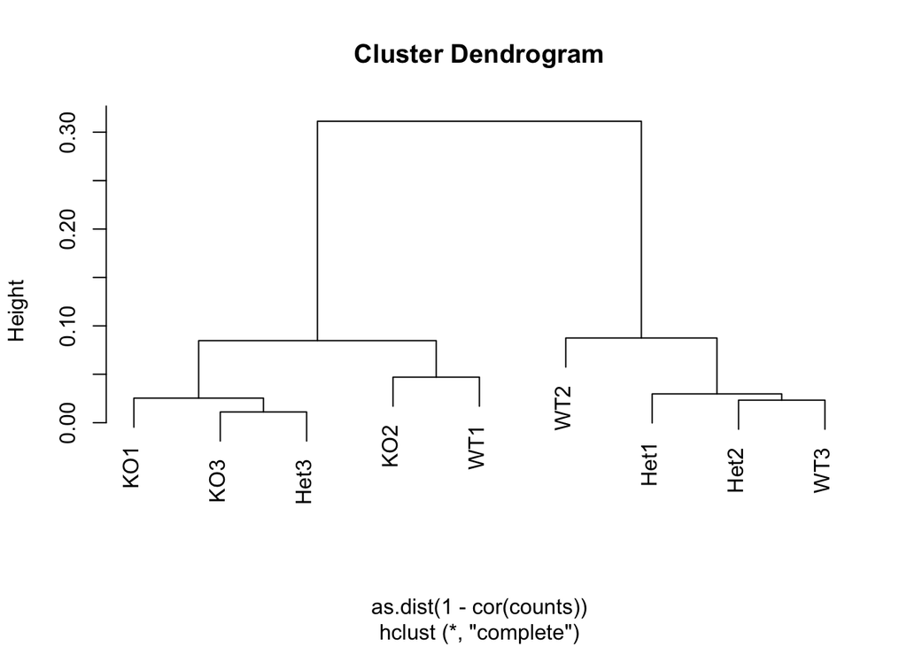

```r
plot(hclust(as.dist(1-cor(counts))))
```

Apply RUV using empirically derived negative controls

```r
## create a data set with phenotype information
colData = data.frame(sample = colnames(counts), genotype = as.factor(rep(c("KO","Het","WT"),each=3)))

## create a DESeq data set
dds = DESeqDataSetFromMatrix(countData = counts,colData = colData,design = ~ genotype)
## Wald test for genotype effect - prior to RUV (to get empirical genes)
dds = DESeq(dds,test="LRT",reduced= ~ 1,fitType="local")
genoEffect = results(dds)
genoEffect = genoEffect[order(genoEffect$pvalue),]

## identify empirical controls genes
empirical <- rownames(tail(genoEffect,2000))

## use RUV to 'normalize' data
seqExpressionSet <- newSeqExpressionSet(as.matrix(counts), phenoData = data.frame(colData, row.names=colnames(counts)))
ruvgSet <- RUVg(seqExpressionSet, empirical, k=3, drop=0)
```

Relative Log Expression - Prior to RUV

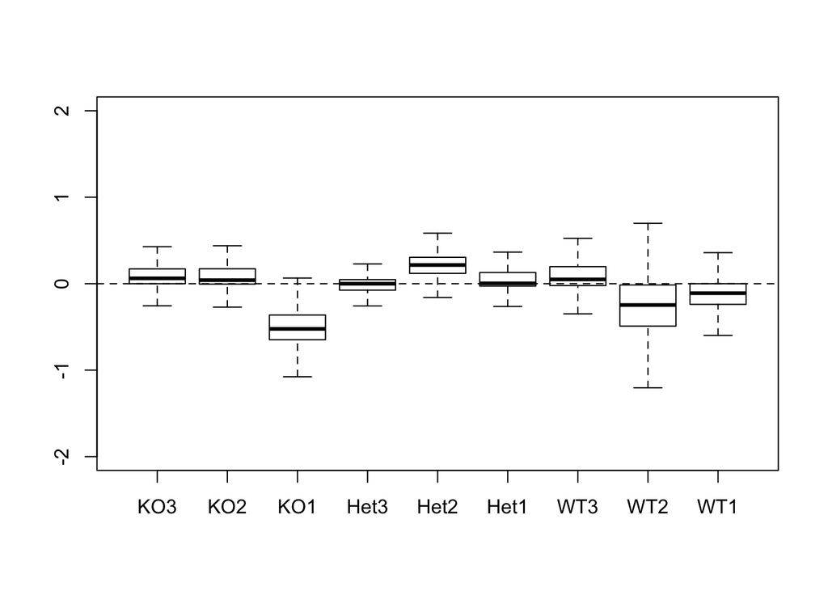

```r
plotRLE(seqExpressionSet, outline=FALSE, ylim=c(-2, 2))
```

Relative Log Expression - After RUV

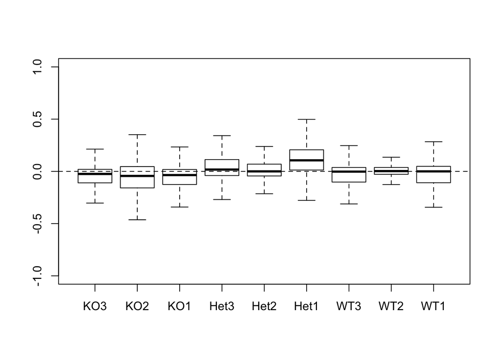

```r
plotRLE(ruvgSet, outline=FALSE, ylim=c(-1, 1))
```

Clustering of Samples After RUV

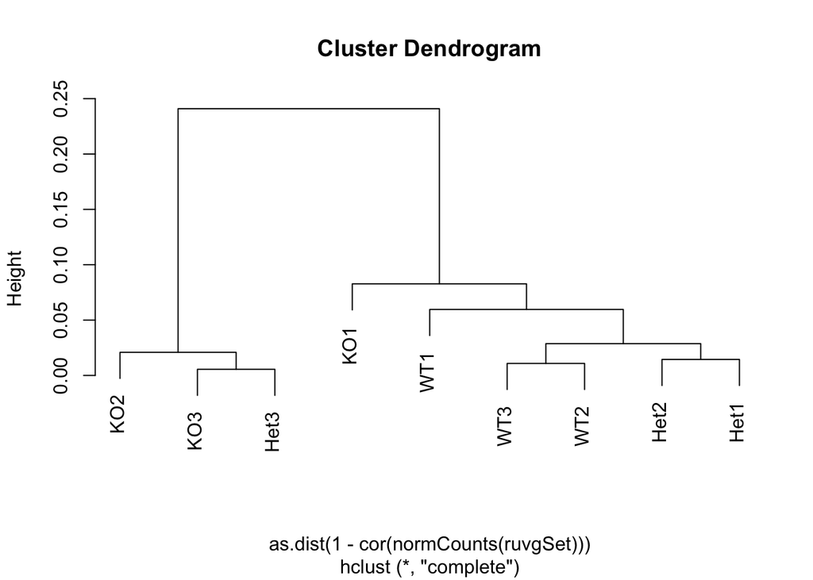

```r
plot(hclust(as.dist(1-cor(normCounts(ruvgSet)))))
```

Differential Expression Analysis

```r
dds2 = DESeqDataSetFromMatrix(countData = counts,colData = pData(ruvgSet),design = ~ genotype + W_1 + W_2 + W_3)
dds2 = DESeq(dds2,test="LRT",reduced= ~ W_1 + W_2 + W_3, fitType="local")
genoEffects = results(dds2)
```

Merge differential expression results with annotation

```r
library(dplyr)
# add annotation information
wAnno = merge(as.data.frame(genoEffects),anno,by.x=0,by.y="transcript_id")
wAnno = wAnno[order(wAnno$pvalue),]

# add information about normalized read counts
norm_cnts = normCounts(ruvgSet)
exp_summary = data.frame(norm_cnts)
exp_summary$KO_median = apply(exp_summary[,c("KO1","KO2","KO3")],1,median)
exp_summary$Het_median = apply(exp_summary[,c("Het1","Het2","Het3")],1,median)
exp_summary$WT_median = apply(exp_summary[,c("WT1","WT2","WT3")],1,median)
exp_summary$KO_pctWT = exp_summary$KO_median/exp_summary$WT_median
exp_summary$Het_pctWT = exp_summary$Het_median/exp_summary$WT_median
exp_summary = exp_summary %>% select(KO_median,Het_median,WT_median,KO_pctWT,Het_pctWT)

###  Gene Summary  ###
gene_summary = wAnno %>% group_by(gene_id) %>% summarize(numTranscripts = length(gene_id))

###  Results Table  ###
wAnno = merge(wAnno,exp_summary,by.x="Row.names",by.y=0)
wAnno = merge(wAnno,gene_summary,by="gene_id")

###  Differentially Expressed Genes  ###
tested_genes = wAnno[!is.na(wAnno$padj),]
tested_genes$KO_pctWT[is.na(tested_genes$KO_pctWT)]=1

tested_genes = tested_genes %>%
  mutate(p05 = padj<0.05,p01 = padj<0.01,p001 = padj<0.001,p0001 = padj<0.0001) %>%
  mutate(grt100 = (KO_pctWT>2 | KO_pctWT<(1/2)), grt50 = (KO_pctWT>1.5 | KO_pctWT<(1/1.5)))

##  Candidate Genes  ##
sigGenes = tested_genes %>%
  filter(padj<0.01 & grt100)
```

Summary of significant transcripts: Number of transcripts: 146 Number of genes: 136